# Homework Vignette

20008

2020-12-17

## first task:including texts and one figure

we use Hald’s cement data to carry out linear regression

```r
library(ridge)
data(Hald)
cement<-data.frame(Hald)
#use Hald's cement data to carry out linear regression
lm.sol<-lm(y~.,data=cement)
#get fitted value
yfit<-predict(lm.sol)
yreal<-cement[,1]
```

from this figure,we can compare the real value and fitted value of y.

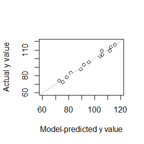

```r
plot(x=yfit, y=yreal, xlab="Model-predicted y value", ylab="Actual y value", xlim=c(60,120),ylim=c(60,120))
abline(a=0,b=1,col="grey")
```

carry out residual analysis to check whether the model assumptions are reasonable.

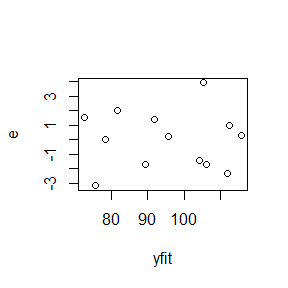

```r
e=residuals(lm.sol)
e.std=rstandard(lm.sol)
plot(e~yfit)
```

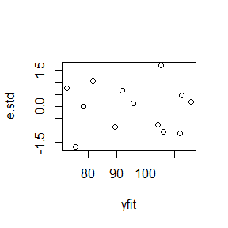

```r
plot(e.std~yfit)
```

## second task:including texts and one table

```r
 xtable::xtable(head(cement))
```

```
#> % latex table generated in R 3.6.3 by xtable 1.8-4 package
#> % Thu Dec 17 22:03:37 2020
#> \begin{table}[ht]
#> \centering
#> \begin{tabular}{rrrrrr}
#>   \hline
#>  & y & X1 & X2 & X3 & X4 \\
#>   \hline
#> 1 & 78.50 & 7.00 & 26.00 & 6.00 & 60.00 \\
#>   2 & 74.30 & 1.00 & 29.00 & 15.00 & 52.00 \\
#>   3 & 104.30 & 11.00 & 56.00 & 8.00 & 20.00 \\
#>   4 & 87.60 & 11.00 & 31.00 & 8.00 & 47.00 \\
#>   5 & 95.90 & 7.00 & 52.00 & 6.00 & 33.00 \\
#>   6 & 109.20 & 11.00 & 55.00 & 9.00 & 22.00 \\
#>    \hline
#> \end{tabular}
#> \end{table}
```

## third task:including latex formulas

for a given mutiple linear regression model:
$$y=X \beta+\epsilon\\ X=(x_1,x_2,...,x_p)\in R^{n×p},\beta=(\beta_1,...,\beta_p)^{T},y=(y_1,y_2,...,y_n)^T$$
$$OLS: minimize\quad \sum_{i=1}^n(y_i-x_i^{T}\beta)^2$$
the estimated value of y:
$$\hat{y}=(X^{'}X)^{-1}X^{'}y$$
other penalized regression methods include:ridge regression,lasso and elastic net. we carry out these methods as follows:
$$minimize\quad \sum_{i=1}^n(y_i-x_i^{T}\beta)^2+\mathcal{P}(\beta,\lambda)$$
$\mathcal{P}(\beta,\lambda)$ represents penalized function.

$$\begin{equation}
\mathcal{P}(\beta,\lambda) =
\begin{cases}
\lambda\sum_{i=1}^p\|\beta_i\|，& lasso\\\\
\lambda\sum_{i=1}^p {\beta_i}^2, & ridge\\
{\lambda}_1\sum_{i=1}^p\|\beta_i\|+{\lambda}_2\sum_{i=1}^p {\beta_i}^2,& elastic\quad net
\end{cases}
\end{equation}$$

## 3.3

cdf of Pareto(a,b):
$$F(x)=1-({\frac{b}{x}})^a(x\ge b>0,a>0).$$
Problem:

- Derive the probability inverse transformation :$F^{-1}(U)$
- Use the inverse transform method to simulate a random sample from the Pareto(2, 2) distribution
- Graph the density histogram of the sample with the Pareto(2, 2) density superimposed for comparison

Solution:
$$F^{-1}(u)=\frac{b}{(1-u)^{\frac{1}{a}}},\quad (0< u<1)$$
$$\Rightarrow\text{pdf of F(x)}:f(x)=\frac{ab^a}{x^{a+1}}(x\ge b>0,a>0)$$

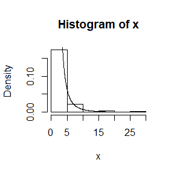

```r
n<-100
u<-runif(n)
a<-2
b<-2
x<-b/(u^(1/a))## the inverse function of F(x)
hist(x,prob=T)
y<-seq(2,20,0.01)
lines(y,a*b^a/y^(a+1))
```

## 3.9

$$f_e(x)=\frac{3}{4}(1-x^2)(|x|\le1)\\ U_1,U_2,U_3\sim U(-1,1)(iid)\\If |U_3|≥ |U_2| and |U_3|≥ |U_1|, deliver\quad U_2; otherwise\quad deliver \quad U_3.$$

Problem:

- Write a function to generate random variates from fe
- construct the histogram density estimate of a large simulated random sample

Solution: Assume the variable we get from the method is $U$.
$$Let \quad x\sim U(0,1),independent\quad variable\quad of \quad U_1,U_2,U_3.$$
Method:If $|U|$ ≤ $x$,accept $U$,otherwise we refuse $U$.The codes are as follows.

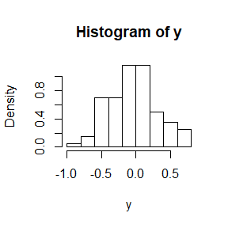

```r
n<-100
y<-numeric(n)
k<-0 #counter for accepted
j<-0#iterations
while(k<n){
  x<-runif(1)#random variable from U(0,1)
  u1<-runif(1,-1,1)
  u2<-runif(1,-1,1)
  u3<-runif(1,-1,1)# generate U1,U2,U3 from U(-1,1)
  j<-j+1
  if(abs(u1)<=abs(u3)&&abs(u2)<=abs(u3))##deliver u2
    {
    if(abs(u2)<=x){
      k<-k+1
      y[k]<-u2
    }
  }
  else  ##deliver u3
    {
    if(abs(u3)<=x){
      k<-k+1
      y[k]<-u3
    }
  }
}
hist(y,prob=T)## y:the simulated random sample with length 10000.
```

## 3.10

Problem:

- Prove that the algorithm given in Exercise 3.9 generates variates from the density fe (3.10).

Proof:
$$U_1,U_2,U_3\sim U(-1,1)_{iid}$$
$$\textit{Assume the variable we generated from the method is U (-1 ≤U ≤1).let x ~ U(0,1)}$$
$$\because|U_1|,|U_2|,|U_3|\sim U(0,1)(iid),let. V_1=|U_1|，V_2=|U_2|， V_3=|U_3|,V=max\{V_1,V_2\}\\\Rightarrow V_1,V_2,V_3\sim_{iid}U(0,1),f_V(v)=2v(由次序统计量的密度函数公式可知)$$

$$\begin{align*}
P(|U|\leq x)=&P\{max(|U_1|,|U_2|)\le |U_3|,|U_2|\le x\}+P\{max(|U_1|,|U_2|)> |U_3|,|U_3|\le x\}\\
=&P(max\{V_1,V_2\}\le V_3,V_2\le x)+P(max\{V_1,V_2\}>V_3,V_3\le x)\\
=&P(V_3\ge V,V_2\le x)+P(V_3\le V,V_3\le x)\\
\end{align*}$$

$$\begin{align*}
其中P(V_3\ge V,V_2\le x)=&\int_0^xdv_2(\int_0^{v_2}dv_1\int_{v_2}^1dv_3+\int_{v_2}^1dv_1\int_{v_1}^1 d{v_3})\\
=&\int_0^xdv_2(\int_0^{v_2}(1-v_2)dv_1+\int_{v_2}^1(1-v_1)dv_1)\\
=&\frac{1}{2}x-\frac{1}{6}x^3\\
P(V_3\le V,V_3\le x)=&\int_0^x dv_3\int_{v_3}^1 2v dv\\
=&\int_0^x(1-v_3^2)dv_3\\
=&x-\frac{1}{3}x^3\\
\end{align*}$$

$$\therefore P(U\leq x)=\frac{3}{4}x-\frac{1}{4}x^3\Rightarrow f_U(x)=\frac{3}{4}-\frac{3}{4}x^2(0\le x\le 1)\\ \because U的分布在[-1,1]上对称，\therefore f_U(x)=\frac{3}{4}(1-x^2)(-1\le x\le 1),证毕.$$

## 3.13

$$F(y)=1-{(\frac{\beta}{\beta+y})}^r(y\ge 0).$$
Problem:

- Generate 1000 random observations from the mixture with r = 4 and β = 2
- Compare the empirical and theoretical distributions by graphing the density histogram of the sample and superimposing the Pareto density curve.

Solution: pdf of y
$$f(y)=\frac{r\beta^r}{(\beta+y)^{r+1}}(y\ge 0)$$
$$F^{-1}(u)=\frac{\beta}{(1-u)^{\frac{1}{r}}}-\beta(0< u <1)$$

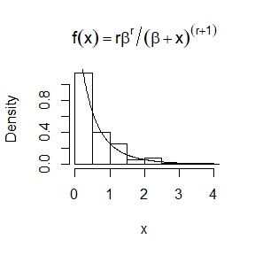

```r
n<-100
u<-runif(n)
beta=2
r=4
x<-beta/(1-u)^(1/r)-beta
hist(x,prob=T,main=expression(f(x)==r*beta^r/(beta+x)^(r+1)))
y<-seq(0,20,0.01)
lines(y,r*beta^r/(beta+y)^(r+1))
```

## 5.1

- Compute a Monte Carlo estimate of $\int_0^\frac{\pi}{3}sintdt$

$$Solution:let.f(t)=sint,g(t)=\frac{\pi}{3}sint,where~ t\sim U(0,\frac{\pi}{3})\\ \therefore \int_0^\frac{\pi}{3}sintdt=\int_0^\frac{\pi}{3}g(t)×\frac{3}{\pi}dt=E[g(T)]~~~(where~T\sim U(0,\frac{\pi}{3}))\\ \textit{The true value of the integral:}\int_0^\frac{\pi}{3}sintdt=-cost|_0^{\frac{\pi}{3}}=0.5\\
\textit{The codes are as follows:}$$

```r
set.seed(12345)
m <- 1e2;
t <- runif(m, min=0, max=pi/3)##Generate random numbers~U(0,pi/3)
hat.f <- mean(sin(t)) * pi/3 ##estimate of f(t)
print(c(hat.f,0.5))
```

```
#> [1] 0.5071247 0.5000000
```

## 5.7

- Use a MC simulation to estimate$\theta$ by the antithetic variate approach and by the simple Monte Carlo method.
- Compute an empirical estimate of the percent reduction in variance using the antithetic variate.
- Compare the result with the theoretical value from Exercise 5.6

$$From \quad 5.6:\theta=\int_0^1e^xdx=e-1≈ 1.718282~~~~~~(true
\quad value)\\$$
1.MC simulation:

```r
m<-1e2
set.seed(12345)
#####The antithetic variate approach ########

t1<-runif(m/2) ##Generate random numbers~U(0,1)
theta1=1/2*((exp(t1))+(exp(1-t1)))##the antithetic estimator

#####The simple Monte Carlo method ##########

t2<-runif(m)
theta2<-exp(t2)##simple MC estimator

##compare the results of antithetic variate approach, simple MC method and true value

print(c(mean(theta1),mean(theta2),exp(1)-1))
```

```
#> [1] 1.719868 1.810376 1.718282
```

```r
####variance reduction######
(var(theta2)-var(theta1))/var(theta2)*100
```

```
#> [1] 98.33709
```

2.Compute an empirical estimate of the percent reduction in variance using the antithetic variate

```r
antithetic<-function(m=1e2,anti=T){
        u<-runif(m/2)
        if(!anti) v<-runif(m/2) else ###simple MC method
                v<-1-u###antithetic variate approach
        t<-c(u,v)
        theta<-exp(t)
        mean(theta)##the estimator
}
n<-100
MC1<-MC2<-numeric(n)
for(i in 1:n){
        MC1[i]<-antithetic(m=1e2)
        MC2[i]<-antithetic(m=1e2,anti=F)
}
print(100*(var(MC2)-var(MC1))/var(MC2))###variance reduction
```

```
#> [1] 95.47839
```

## 5.11

- $\hat{θ_1}$ and $\hat{θ_2}$ are any two unbiased estimators of θ,find the value $c^{∗}$ =$min${$Var$($\hat{θ_c}$ = $c$$\hat{θ_1}$ +(1 − $c$)$\hat{θ_2}$)} in equation (5.11).

Solution:
$$Var(c\hat{\theta_1}+(1-c)\hat{\theta_2})=c^2Var(\hat{\theta_1})+(1-c)^2Var(\hat{\theta_2})+2c(1-c)Cov(\hat{\theta_1},\hat{\theta_2})\\
\textit{Derivate the above formula by c: }\\
\Rightarrow 2cVar(\hat{\theta_1})+2(c-1)Var(\hat{\theta_2})+2(1-2c)Cov(\hat{\theta_1},\hat{\theta_2})=0\\
\Rightarrow c^*=\frac{Var\hat{\theta_2}-Cov(\hat{\theta_1},\hat{\theta_2})}{Var\hat{\theta_1}+Var\hat{\theta_2}-2Cov(\hat{\theta_1},\hat{\theta_2})}\\
\textit{Derivate the above formula again,we have: }\\
2(Var(\hat{\theta_1})+Var(\hat{\theta_2})-2Cov(\hat{\theta_1},\hat{\theta_2}))\ge0\\
\therefore c^* \textit{minimizes the variance of the estimator.}\\
\textit{When the two estimators are antithetic: (Which is example (5.11))}\\ Cov(\hat{\theta_1},\hat{\theta_2})=-Var(\hat{\theta_1})\quad\therefore c^*=\frac{1}{2}\\
\textit{So in general case}:c^*=\frac{Var\hat{\theta_2}-Cov(\hat{\theta_1},\hat{\theta_2})}{Var\hat{\theta_1}+Var\hat{\theta_2}-2Cov(\hat{\theta_1},\hat{\theta_2})}$$

## 5.13

- Find two importance functions $f_1$,$f_2$ that are supported on(1,$\infty$) and close to
  $$g(x)=\frac{x^2}{\sqrt{2\pi}}e^{-x^2/2},(x>1)$$
- which produces the smaller variance in estimating $\int_1^\infty \frac{x^2}{\sqrt{2\pi}}e^{-x^2/2}$
- Explain.

$$f_1(x)=xe^{-x^2/2}~~~~(x>0)\\
(f_1(x)~is~pdf~of~Weibull~distribution~with~scale~parameter~\sqrt{2},shape~parameter~2)\\
g(x)/f_1(x)=\frac{1}{\sqrt{2\pi}}x\\
f_2(x)=\Gamma(3,2)=4x^2e^{-2x}~~~(x>0)
\\And~g(x)/f_2(x)=\frac{1}{4\sqrt{2\pi}}e^{2x-x^2/2}\\
(PS:Another~option:f_1(x)=~~~\frac{1}{\sqrt{2\pi}}e^{-x^2/2}(-\infty<x<\infty)\\
\textit{Which is pdf of normal distribution.}~Then~g(x)/f_1(x)=x^2)\\
\textit{The codes are as follows:}$$

```r
m<-1e2
g<-function(x){
  exp(-x^2/2)*x^2/sqrt(2*pi)*(x>1)
  }


#####using f1######
x<-rweibull(m,2,sqrt(2))
gf<-g(x)/dweibull(x,2,sqrt(2))
theta1<-mean(gf)
se1<-sd(gf)



####using f2######
x<-rgamma(m,3,2)
gf<-g(x)/dgamma(x,3,2)
theta2<-mean(gf)
se2<-sd(gf)


####PS:Using Normal ditribution#######
x<-rnorm(m)
gf<-g(x)/dnorm(x)
theta3<-mean(gf)
se3<-sd(gf)

####In one simulation
####theta.hat<-(0.3977415 0.4062168 0.383093)
####se<-(0.3589789 0.3008697 1.096234)
theta.hat<-c(theta1,theta2,theta3)

se<-c(se1,se2,se3)
rbind(theta.hat,se)
```

```
#>                [,1]      [,2]      [,3]
#> theta.hat 0.3881703 0.3707677 0.3369866
#> se        0.3608202 0.3095512 0.9626223
```

$$From~the~above~results: ~Normal~distribution~has~the~worst~performance~~\\
\therefore~we~use~f_1(x)~and~f_2(x)~in~the~following~discussion.\\
We~can~see~\Gamma(3,2)~produces~smaller~variance\\
\textit{the discussion and plots are as follows}.$$
First,we draw the curve of g,f1 and f2 and compare them with each other.

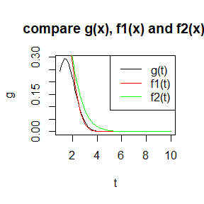

```r
t<-seq(1,10,0.1)
g<-exp(-t^2/2)*t^2/sqrt(2*pi)
f1<-dweibull(t,2,sqrt(2))
f2<-dgamma(t,3,2)

####get the curve of g,f1 and f2####
plot(t,g,type="l",col="black",main="compare g(x), f1(x) and f2(x) ")
lines(t,f1,col="red")
lines(t,f2,col="green")
legend("topright",legend =c('g(t)','f1(t)',"f2(t)") ,lty=1,col=c("black","red","green"))
```

Then,we draw the ration functions and make comparision,which are g/f1 and g/f2.

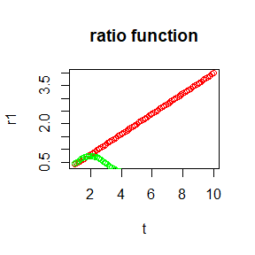

```r
t<-seq(1,10,0.1)
 g<-exp(-t^2/2)*t^2/sqrt(2*pi)
 f1<-dweibull(t,2,sqrt(2))
 f2<-dgamma(t,3,2)
r1<-g/f1
r2<-g/f2
plot(t,r1,col="red")
points(t,r2,col="green")
title(main="ratio function")
```

Explain:
$$We~can~see:~g(x)/f_1(x)=\frac{1}{\sqrt{2\pi}}x\\
While~g(x)/f_2(x)=\frac{1}{4\sqrt{2\pi}}e^{2x-x^2/2}\\
From~the~above~plots,the~curve~of~g(x)/f_2(x)~is~more~"close"~to~constant,\\
which~means~f_2(x)~is~more~"close"~to~g(x).\\
\therefore~f_2(x)=\Gamma(3,2)~produces~smaller~variance.$$

## 5.15

- Obtain the stratified importance sampling estimate in Example 5.13
- compare it with the result of Example 5.10.

$$In~example~5.13:f_3(x)=e^{-x}/(1-e^{-1})~~~(0<x<1)\\
Divide~(0,1)~into~five~subintervals~~(j/5， (j +1)/5)\\
The~codes~are~as~follows:$$

```r
###example 5.10##
m<-1e2
g<-function(x)
  exp(-x-log(1+x^2))*(x > 0)*(x < 1)
f3<-function(x)
  exp(-x)/(1-exp(-1))

##### using f3 ####
t <- runif(m) #inverse transform method for f3
x <- -log(1-t*(1 - exp(-1)))
gf <- g(x) / ((exp(-x) / (1-exp(-1))))
theta1<- mean(gf)
se1<- sd(gf)


###Stratified importance sampling #####
k<-5     ##number of stratum
r<-m/k   ##replicates per stratum
T2<-numeric(k)
var<-numeric(k)
for (i in 1:k) {
  u<-  runif(r,(i-1)/k,i/k)
  x<- -log(1-u*(1-exp(-1)))
#### estimated mean in each subinterval
  T2[i]<-mean(g(x)/f3(x))

####estimated variance in each subinterval
  var[i]<-sd(g(x)/f3(x))^2
}
theta2<-mean(T2)
se2<-sqrt(sum(var)/r)

###compare###
print(c(theta1,theta2))
```

```
#> [1] 0.5296946 0.5233618
```

```r
print(c(se1,se2))
```

```
#> [1] 0.09475997 0.01192385
```

Clearly, Stratified importance sampling achieves smaller variance, better than importance sampling method.

## 6.4

- Suppose that $X_1$,…,$X_n$ are a random sample from a from a lognormal distribution with unknown parameters.
- Construct a 95% confidence interval for the parameter µ.
- Use a Monte Carlo method to obtain an empirical estimate of the confidence level.

$$The~pdf~of~X:f(x;\mu,\sigma)=(1/\sqrt{2\pi}\sigma)exp[-1/2\sigma^2(lnx-\mu)^2]I_{\{x>0\}}\\
Where~ln(X)\sim N(\mu,\sigma^2)\\
Set.~ Y=ln X,~~~Then~Y_1,Y_2,...,Y_n~ is~ a ~random~sample~from~N(\mu,\sigma^2)\\
\therefore ~The~estimate~of~\mu:\\ \hat\mu=\bar{Y}=\frac{1}{n}\sum_{i=1}^nY_i\\
Also,we~have\quad S^2=\frac{1}{n-1}\sum_{i=1}^n(logX_i-\hat\mu)^2\\
\Rightarrow\frac{\sqrt{n}(\hat\mu-\mu)}{S}\sim t(n-1)\\
\therefore~(1-\alpha)CI~is~:(\hat\mu±\frac{S}{\sqrt{n}}t_{1-\alpha/2}(n-1))\\
Monte~Carlo~method——Estimate~mean~of~\mu\\
1.\hat\mu=\frac{1}{n}\sum_i lnX_i,Which~is~based ~on~m~replicates\\
2.Generate~random~samples~X^{(j)}=(x_1^{(j)},...,x_n^{(j)}).\\
3.Set~Y^{(j)}=(ln(x_1^{(j)}),...,ln(x_1^{(j)}))=(y_1^{(j)},...,y_n^{(j)})\\
4.\hat\mu^{(j)}=\frac{1}{n}\sum_iy_i^{(j)}~~~~~~~~~\Rightarrow~~~~~~~ \hat\mu=\frac{1}{m}\sum_j\hat\mu^{(j)}\\
Monte~Carlo~method——Estimate~the~standard~error:\\
1.\hat{s^2}^{(j)}=\frac{1}{n-1}\sum_i (y_i^{(j)}-\hat\mu^{(j)})^2\\
2.\hat{s^2}=\frac{1}{m}\sum_j\hat{s^2}^{(j)},and~\hat s=\sqrt{s}$$

```r
mu<-1;
sigma<-1
n<-20
alpha<-0.05
UCL<-replicate(10,expr = {
  x<-rlnorm(n,mu,sigma)
  y<-log(x)
  abs(sqrt(n/var(y))*(mean(y)-mu))
})
sum(UCL<qt(1-alpha/2,n-1))
```

```
#> [1] 9
```

```r
mean(UCL<qt(1-alpha/2,n-1))
```

```
#> [1] 0.9
```

## 6.5

- Suppose a 95% symmetric t-interval is applied to estimate a mean, but the sample data are non-normal.The probability that the confidence interval covers the mean is not equal to 0.95.
- Use a Monte Carlo experiment to estimate the coverage probability of the t-interval for random samples of $\chi^2$(2) data with sample size n = 20.
- Compare your t-interval results with the simulation results in Example 6.4.

$$检验统计量~T=\frac{\sqrt{n}(\bar x-\mu)}{s}\sim t(n-1)\\
\therefore (1-\alpha)CI~for~\mu:\bar x±t_{1-\alpha/2}(n-1)s/\sqrt n\\
Which~in~MC~experiment~is~:mean(x)±t_{1-\alpha/2}(n-1)sd(x)/\sqrt n\\
The~codes~are ~as~follows:$$

```r
####Example 6.4 ： N(0,sigma^2=4)#####
n<-20
alpha<-0.05

####example 6.4
UCL.norm<-replicate(10,expr={
  x<-rnorm(n,mean=0,sd=2)
  ((mean(x)+qt(1-alpha/2,n-1)*sd(x)/sqrt(n)>0)&&(mean(x)-qt(1-alpha/2,n-1)*sd(x)/sqrt(n)<0))####the mean of x=0
})
sum(UCL.norm==TRUE)###check if the CI covers 0
```

```
#> [1] 10
```

```r
####Chi分布
###Using t-interval
UCL.chisq<-replicate(10,expr={
  y<-rchisq(n,df=2)
  ((mean(y)+qt(1-alpha/2,n-1)*sd(y)/sqrt(n)>2)&&(mean(y)-qt(1-alpha/2,n-1)*sd(y)/sqrt(n)<2))#### the mean of x=2
})
sum(UCL.chisq==TRUE) ###check if the CI covers 2
```

```
#> [1] 9
```

```r
###Using example 6.4
UCL.chi<-replicate(10,expr={
  y<-rchisq(n,df=2)
  (n-1)*var(y)/qchisq(alpha,df=n-1)
})
sum(UCL.chi>4)  ###check if CI covers 4(sigma^2)
```

```
#> [1] 8
```

## 6.7

- Estimate the power of the skewness test of normality against symmetric Beta($\alpha$, $\alpha$) distributions and comment on the results.
- Are the results different for heavy-tailed symmetric alternatives such as t($\nu$)?

```r
n<-c(10,20,30,50,100,500)##sample size
cv<-qnorm(0.975,0,sqrt(6*(n-2)/((n+1)*(n+3))))

skewness<-function(x){
  barx<-mean(x)
  s2<-mean((x-barx)^2)
  s3<-mean((x-barx)^3)
  return(s3/s2^1.5)
}

r1<-numeric(length(n))
##store results for beta distribution
r2<-numeric(length(n))
##store results for t distribution

B<-1e2 ##repeat each simulation
a<-function(a){
for(i in 1:length(n)){
  test<-numeric(B)
  compare<-numeric(B)
  for(j in 1:B){
    t<-seq(0,1,length=n[i])
    ## generate samples from beta distribution##
    x<-rbeta(t,a,a)
    ##obtain samples from t distribution
    y<-rt(n[i],n[i]-1)
    test[j]<-as.integer(abs(skewness(x))>=cv[i])
    compare[j]<-as.integer(abs(skewness(y))>=cv[i])
  }
  r1[i]<-mean(test)
  r2[i]<-mean(compare)
}
  r<-cbind(r1,r2)
  colnames(r)<-c("beta","t")
  rownames(r)<-c("10","20","30","50","100","500")
  return(r)
}
a(0.05)
```

```
#>     beta    t
#> 10  0.16 0.13
#> 20  0.07 0.05
#> 30  0.07 0.08
#> 50  0.04 0.05
#> 100 0.02 0.06
#> 500 0.03 0.05
```

```r
a(0.5)
```

```
#>     beta    t
#> 10  0.04 0.10
#> 20  0.02 0.08
#> 30  0.00 0.07
#> 50  0.01 0.08
#> 100 0.00 0.01
#> 500 0.00 0.05
```

```r
a(1)
```

```
#>     beta    t
#> 10  0.01 0.09
#> 20  0.01 0.09
#> 30  0.01 0.05
#> 50  0.00 0.09
#> 100 0.00 0.02
#> 500 0.01 0.03
```

## 6.8

- Refer to Example 6.16. Repeat the simulation, but also compute the F test of equal variance, at significance level $\hat\alpha$=0.055.
- Compare the power of the Count Five test and F test for small, medium, and large sample sizes. (F test is not applicable for non-normal distributions.)

Solution：

```r
### Example 6.16 ###

sigma1<-1
sigma2<-1.5
u1<-u2<-0

##Count Five test##
Countfive<-function(x,y){
  sx<-x-mean(x)
  sy<-y-mean(y)
  out1<-sum(sx>max(sy))+sum(sx<min(sy))
  out2<-sum(sy>max(sx))+sum(sy<min(sx))
  ##return 1##
  return(as.integer(max(c(out1,out2))>5))
}

m<-1e2
power1<-function(n1,n2){
  ### Countfive test ##
  r<-replicate(m,expr={
  x<-rnorm(n1,u1,sd=sigma1)
  y<-rnorm(n2,u2,sd=sigma2)
  x<-x-mean(x)
  y<-y-mean(y)
  Countfive(x,y)
  })
  return(mean(r))
}

power2<-function(n1,n2){
  ###F test ##
  r<-replicate(m,expr={
    x<-rnorm(n1,u1,sd=sigma1)
    y<-rnorm(n2,u2,sd=sigma2)
    ftest<-var.test(x,y)$p.value
    return(ftest)
    })
  sum(r>0.055)/m
}
data1<-c(power1(20,20),power1(20,30),power1(50,50),power1(100,100),power1(200,200),power1(500,500))
data2<-c(power2(20,20),power2(20,30),power2(50,50),power2(100,100),power2(200,200),power2(500,500))
d<-matrix(cbind(data1,data2),nrow=2,byrow=T)
rownames(d)<-c("Countfive test","F test")
colnames(d)<-c("(20,20)","(20,30)","(50,50)","(100,100)","(200,200)","(500,500)")
d
```

```
#>                (20,20) (20,30) (50,50) (100,100) (200,200) (500,500)
#> Countfive test    0.35    0.61    0.66      0.81      0.95      0.98
#> F test            0.63    0.48    0.25      0.03      0.00      0.00
```

## 6.C

- Repeat Examples 6.8 and 6.10 for Mardia’s multivariate skewness test. Mardia proposed tests of multivariate normality based on multivariate generalizations of skewness and kurtosis. If $X$ and $Y$are iid, the multivariate population skewness $\beta_{1,d}$ is defined by Mardia as $\beta_{1,d}=E[(X-\mu)^{T}\Sigma^{-1}(Y-\mu)]^3$
- Under normality, $\beta_{1,d}$ = 0. The multivariate skewness statistic is $b_{1,d}=\frac{1}{n^2}\sum_{i,j=1}^n((X_i-\hat{X})^T \hat{\Sigma}^{-1}(X_j-\hat X))^3$
- The asymptotic distribution of $nb_{1,d}/6$ is chisquared with $d(d +1)(d +2) /6$ degrees of freedom.

```r
###Example 6.8###
library(MASS)
n <- c(10,20,50,100) #sample size

mardia <- function(x) {
  mx<- mean(x)
  n <- nrow(x)
  m <- 1/n^2*sum(((x-mx)%*%solve(cov(x))%*%t(x-mx))^3)
  return(m)
}

reject <- numeric(length(n))
m <- 1e2
s <- matrix(c(1,0,0,1),2,2)

r<-function(d){
for (i in 1:length(n)) {
  test <- numeric(m)  #test decisions
  for (j in 1:m) {
    x <- mvrnorm(n[i],c(0,0),s)##generate x
    cv<-qchisq(0.975,d*(d+1)*(d+2)/6)#crit.value
    test[j] <- as.integer(abs(mardia(x)) >= 6*cv/n[i])
  }
  reject[i] <- mean(test)
}
  return(reject)
}
##set d=2 and d=3##
##The results##
r(2)
```

```
#> [1] 0.14 0.08 0.13 0.13
```

```r
r(3)
```

```
#> [1] 0.02 0.03 0.00 0.02
```

## Discussion:

- If we obtain the powers for two methods under a particular simulation setting with 10,000 experiments: say, 0.651 for one method and 0.676 for another method. Can we say the powers are different at 0.05 level?
- What is the corresponding hypothesis test problem?
- What test should we use? Z-test, two-sample t-test, paired-t test or McNemar test?
- What information is needed to test your hypothesis?

Discussion:

Not likely.

- The corresponding hypothesis test problem: $H_0:p_1=p_2~~vs~~H_1:p_1 \neq p_2$
- Except two-sample t-test, which is used for samll samples.
- The sample size we need, the distribution of the test estimates adn the significance level.

## 7.1 * Compute a jackknife estimate of the bias and the standard error of the correlation statistic in Example 7.2.

Solution:

$$\widehat{bias}_{jack}=(n-1)(\overline{\hat\theta_{(.)}}-\hat\theta),~~where~~\overline{\hat\theta_{(.)}}=\frac{1}{n}\sum_i\hat\theta_{(i)}\\
For~~standard~error：~\widehat se_{jack}=\sqrt{(n-1)/n\sum_i(\hat\theta_{(i)}-\overline{\hat\theta_{(.)}})^2}.\\
The~codes~are~as~follows:$$

```r
###In Example 7.2, dataset: law ###
data(law,package="bootstrap")
n<-nrow(law)
l<-law$LSAT
gpa<-law$GPA

cor.jack<-numeric(n)
for( i in 1:n){
        cor.jack[i]<-cor(l[-i],gpa[-i])
}
###estimate bias###
bias<-(n-1)*(mean(cor.jack)-cor(l,gpa))
###estimate standard error###
se<-sqrt((n-1)*mean((cor.jack-mean(cor.jack))^2))
print(cbind(rawdata=cor(l,gpa),bias=bias,se=se))
```

```
#>        rawdata         bias        se
#> [1,] 0.7763745 -0.006473623 0.1425186
```

## 7.5

- Refer to Exercise 7.4. Compute 95% bootstrap confidence intervals for the mean time between failures 1/λ by the standard normal, basic, percentile, and BCa methods.
- Compare the intervals and explain why they may differ.

```r
library(boot)
data(aircondit,package="boot")

hour<-aircondit$hours

###use meantime function to obtain the estimate for mean and sd
meantime<-function(d,index){
        m<-mean(d[index])
        n<-length(index)
        s<-(n-1)*var(d[index])/n^2
        c(m,s)
}

boot.air<-boot(hour,meantime,R=5)
print(boot.air)
###using boot.ci function to obtain CI by different method###
boot.ci(boot.air,conf=0.95,type=c("norm","basic","perc","bca"))
```

[output not shown]

Explain：

- The four methods are based on different assumptions and different transforms.
- For normal CI: We assume the distribution of $\hat\theta$ is normal or large sample size as well as $\hat\theta$ being unbiased.
- For Basic CI: it substracts the observed statistic and use the quantiles of the transformed sample to calculate.
- For percentile CI:it uses the empirical distribution of the replicates to obtain quantiles, and it has better coverage performance.
- For Bca: modified version of percentile intervals,yet may be unstable.

## 7.8

- Refer to Exercise 7.7. Obtain the jackknife estimates of bias and standard error of $\hat\theta$.

```r
data(scor,package="bootstrap")
n<-nrow(scor)
lambda<-eigen(cov(scor))$values
mec<-scor[,1]
vec<-scor[,2]
alg<-scor[,3]
ana<-scor[,4]
sta<-scor[,5]
###the estimate###
theta<-lambda[1]/sum(lambda)

lambda.jack<-numeric(n)
for( i in 1:n){
        scor.hat<-cbind(mec[-i],vec[-i],alg[-i],ana[-i],sta[-i])
        lambda.hat<-eigen(cov(scor.hat))$values
        lambda.jack[i]<-lambda.hat[1]/sum(lambda.hat)
}
###estimate bias###
bias<-(n-1)*(mean(lambda.jack)-theta)
###estimate standard error###
se<-sqrt((n-1)*mean((lambda.jack-mean(lambda.jack))^2))
print(cbind(rawdata=theta,bias=bias,se=se))
```

```
#>       rawdata        bias         se
#> [1,] 0.619115 0.001069139 0.04955231
```

## 7.11

- In Example 7.18, leave-one-out (n-fold) cross validation was used to select the best fitting model.
- Use leave-two-out cross validation to compare the models.

```r
###the 4 models are from example 7.17###
library(DAAG)
library(boot)
attach(ironslag)
n<-length(magnetic)

t<- seq(10, 40, .1)
###model 1: linear
mod1 <- lm(magnetic ~ chemical)

###model 2:quadratic
mod2 <- lm(magnetic ~ chemical + I(chemical^2))


###model 3: exponential
mod3 <- lm(log(magnetic) ~ chemical)


###model 4:log-log
mod4 <- lm(log(magnetic) ~ log(chemical))

####leave-two-out###
###assign n*n matrix for each time 's error###
###each time randomly pick i and j###
###take the average of the two prediction errors###
e1<-e2<-e3<-e4<-matrix(nrow=n,ncol=n)
I<-rep(1,n^2)
for(i in 1:n){
        y<-magnetic[-i]
        x<-chemical[-i]
        for(j in 1:n){
                y<-y[-j]
                x<-x[-j]
               ###linear model###
                J1<-lm(y~x)
                yhat11<-J1$coef[1]+J1$coef[2]*chemical[i]
                yhat12<-J1$coef[1]+J1$coef[2]*chemical[j]
                e1[i,j]<-0.5*((magnetic[i]-yhat11)^2+(magnetic[j]-yhat12)^2)
               ###quadratic model###
                J2 <- lm(y ~ x + I(x^2))
                yhat21<-J2$coef[1]+J2$coef[2]*chemical[i]+J2$coef[3]*chemical[i]^2
                 yhat22<-J2$coef[1]+J2$coef[2]*chemical[j]+J2$coef[3]*chemical[j]^2
                 e2[i,j]<-0.5*((magnetic[i]-yhat21)^2+(magnetic[j]-yhat22)^2)
              ###exponential model###
                 J3 <- lm(log(y) ~ x)
                 yhat31 <- exp(J3$coef[1] + J3$coef[2] * chemical[i])
                 yhat32 <- exp(J3$coef[1] + J3$coef[2] * chemical[j])
                 e3[i,j]<-0.5*((magnetic[i]-yhat31)^2+(magnetic[j]-yhat32)^2)
              ###log-log model###
                 J4 <- lm(log(y) ~ log(x))
                 yhat41 <- exp(J4$coef[1] + J4$coef[2] * log(chemical[i]))
                 yhat42 <- exp(J4$coef[1] + J4$coef[2] * log(chemical[j]))
                 e4[i,j]<-0.5*((magnetic[i]-yhat41)^2+(magnetic[j]-yhat42)^2)

        }
}
###estimate for leave-two-out ###
E<-function(matr){
        sum(colSums(matr))/(n*n)
}

leaveoneout<-c(19.55644, 17.85248 ,18.44188 ,20.45424)
leavetwoout<-c(E(e1),E(e2),E(e3),E(e4))
cbind(leaveoneout,leavetwoout)
```

```
#>      leaveoneout leavetwoout
#> [1,]    19.55644    18.91125
#> [2,]    17.85248    17.03593
#> [3,]    18.44188    17.61447
#> [4,]    20.45424    19.77453
```

- We can see: the second method, which is quadratic model performs the best and the last method which is log-log model performs worst, same as leave-one-out method.
- Yet, leave-two-out method generally gets smaller prediction error compared with the former leave-one-out model.
- I assume it is due to the average process, which can reduce prediction error.

## Exercise 8.3

- The Count 5 test for equal variances in Section 6.4 is based on the maximum number of extreme points. Example 6.15 shows that the Count 5 criterion is not applicable for unequal sample sizes.
- Implement a permutation test for equal variance based on the maximum number of extreme points that applies when sample sizes are not necessarily equal.

```r
set.seed(12345)

# Count Five test
countfive<-function(x, y) {
 ##centralize x and y##
sx<-x - mean(x)
sy<-y - mean(y)
out1<-sum(sx > max(sy)) + sum(sx< min(sy))
out2 <- sum(sy> max(sx)) + sum(sy < min(sx))
# return 1 (reject) or 0 (do not reject H0)
return(as.integer(max(c(out1, out2)) > 5))
}
# Count Five test permutation
count_permutation<-function(z) {
n <-length(z)
k<-1:(n/2)
x <-z[k]
y <-z[-k]
sx <-x - mean(x)
sy<-y - mean(y)
out1<-sum(sx > max(sy)) + sum(sx< min(sy))
out2 <- sum(sy> max(sx)) + sum(sy < min(sx))
# return 1 (reject) or 0 (do not reject H0)
return(as.integer(max(c(out1, out2)) > 5))
}

per = function(z,m) {
  n <- length(z)
  r<- numeric(m)
  for (i in 1: m){
      p = sample(1:n ,n ,replace = FALSE)
      r[i] = count_permutation(z[p])
  }
  return(mean(r))
}


u1<-u2<-0
s1<-s2<-1
m<-1e2

compare<-function(n1,n2){
p1 = mean(replicate(m, expr={
x = rnorm(n1, u1, s1)
y = rnorm(n2, u2, s2)
x = x - mean(x) #centered by sample mean
y = y - mean(y)
countfive(x, y)
}))
p2 = mean(replicate(m, expr={
x = rnorm(n1, u1, s1)
y = rnorm(n2, u2, s2)
x = x - mean(x) #centered by sample mean
y = y - mean(y)
z = c(x,y)
per(z,m)
})<0.05)
p<-c(p1,p2)
return(p)
}
p<-cbind(compare(20,20),compare(20,30),compare(20,50))
rownames(p)<-c("Countfive","permutation")
colnames(p)<-c("(20,20)","(20,30)","(20,50)")
p
```

```
#>             (20,20) (20,30) (20,50)
#> Countfive      0.07    0.13    0.24
#> permutation    0.45    0.36    0.15
```

## Design experiments(NN,energy,ball)

- Unequal variances and equal expectations
- Unequal variances and unequal expectations
- Non-normal distributions: t distribution with 1 df(heavy-tailed distribution) bimodel distribution(mixture of two normal distributions)
- Unbalanced samples (say, 1 case versus 10 controls)

```r
###First load packages we need###
####For NN test###
library(RANN)
####For energy test###
library(energy)
library(boot)
###For ball test###
library(Ball)
```

For situation (1) and situation (2)

```r
###From the slides: Tn function###
Tn <- function(z, ix, sizes,k) {
  n1 <- sizes[1]
  n2 <- sizes[2]
  n <- n1 + n2
  if(is.vector(z)) z <- data.frame(z,0);
  z <- z[ix, ]
  NN <- nn2(data=z, k=k+1)
  block1 <- NN$nn.idx[1:n1,-1]
  block2 <- NN$nn.idx[(n1+1):n,-1]
  i1 <- sum(block1 < n1 + .5)
  i2 <- sum(block2 > n1+.5)
  return((i1 + i2) / (k * n))
}

set.seed(12345)
m<-100
k<-3
n1<-n2<-50
n <- n1+n2
N = c(n1,n2)
eqdist.nn <- function(z,sizes,k){
   boot.obj <- boot(data=z,statistic=Tn,R=999,
   sim = "permutation", sizes = sizes,k=k)
   ts <- c(boot.obj$t0,boot.obj$t)
   p.value <- mean(ts>=ts[1])
   list(statistic=ts[1],p.value=p.value)
}
 p.values <- matrix(NA,m,3)
 power.compare<-function(mu1,mu2,s1,s2,a){
   x <- rnorm(n1,mu1,s1)
   y <- rnorm(n2,mu2,s2)
   z <- c(x,y)
   for(i in 1:m){
   ### t distribution
   p.values[i,1] <- eqdist.nn(z,N,k)$p.value
   p.values[i,2] <- eqdist.etest(z,sizes=N,R=999)$p.value
   p.values[i,3] <-bd.test(x,y,R=999,seed=i*12345)$p.value
}
 pow<- colMeans(p.values<a)
 names(pow)<-c("NN","energy","Ball")
 return(pow)
 }

###Unequal variances and equal expectations###
power.compare(0,0,1,1.5,0.055)
###Unequal variances and unequal expectations###
power.compare(0.5,0,1,1.5,0.02)
```

[output not shown]

For situation (3). Bimodel distribution: Set $X\sim 0.5N(0,1)+0.5N(1,1)$ And $Y\sim 0.5N(0,1.5)+0.5N(1,1.5)$

```r
set.seed(12345)
m<-100
k<-3
n1<-n2<-50
n <- n1+n2
N = c(n1,n2)
  eqdist.nn <- function(z,sizes,k){
   boot.obj <- boot(data=z,statistic=Tn,R=999,
   sim = "permutation", sizes = sizes,k=k)
   ts <- c(boot.obj$t0,boot.obj$t)
   p.value <- mean(ts>=ts[1])
   list(statistic=ts[1],p.value=p.value)
}
 pt.values <- matrix(NA,m,3)
###t distribution###
 for(i in 1:m){
   ### t distribution
   x <- rt(n1,df=1)
   y <- rt(n2,df=1)
   z <- c(x,y)
   pt.values[i,1] <- eqdist.nn(z,N,k)$p.value
   pt.values[i,2] <- eqdist.etest(z,sizes=N,R=999)$p.value
   pt.values[i,3]<-bd.test(x,y,R=999,seed=i*12345)$p.value
}
 alpha.t <- 0.2
 pow.t <- colMeans(pt.values<alpha.t)
 names(pow.t)<-c("NN","energy","Ball")
 pow.t
```

[output not shown]

```r
### Bimodel distribution###
 pb.values <- matrix(NA,m,3)
 for(i in 1:m){
   ### t distribution
   x <- 0.5*rnorm(n1,0,1)+0.5*rnorm(n1,1,1)
   y <- 0.5*rnorm(n1,0,1.5)+0.5*rnorm(n1,1,1.5)
   z <- c(x,y)
   pb.values[i,1] <- eqdist.nn(z,N,k)$p.value
   pb.values[i,2] <- eqdist.etest(z,sizes=N,R=999)$p.value
   pb.values[i,3] <-bd.test(x,y,R=999,seed=i*12345)$p.value
}
 alpha.b <- 0.2
 pow.b <- colMeans(pb.values<alpha.b)
 names(pow.b)<-c("NN","energy","Ball")
 pow.b
```

[output not shown]

For situation(4), set$n_1=10,n_2=100$

```r
set.seed(12345)
n1<-10
n2<-100
n <- n1+n2
N = c(n1,n2)
m<-50
power.compare<-function(mu1,mu2,s1,s2,a){
   x <- rnorm(n1,mu1,s1)
   y <- rnorm(n2,mu2,s2)
   z <- c(x,y)
   for(i in 1:m){
   ### t distribution
   pt.values[i,1] <- eqdist.nn(z,N,3)$p.value
   pt.values[i,2] <- eqdist.etest(z,sizes=N,R=999)$p.value
   pt.values[i,3] <-bd.test(x,y,R=999,seed=i*12345)$p.value
}
 alpha <- a
 pow<- colMeans(pt.values<a)
 names(pow)<-c("NN","energy","Ball")
 return(pow)
}
power.compare(0,0,1,1.5,0.1)
```

[output not shown]

## Exercise 9.4

- Implement a random walk Metropolis sampler for generating the standard Laplace distribution (see Exercise 3.2).
- For the increment, simulate from a normal distribution.
- Compare the chains generated when different variances are used for the proposal distribution.
- Compute the acceptance rates of each chain.

Solution: The standard Laplace distribution $f(x)=\frac{1}{2}e^{-|x|}$

```r
rv.metro<-function(s,x0,N){
  ##s: different sigma for different variances##
  ##x0:initial value##
  ##N:length of the chain##
  x<-numeric(N)
  u<-runif(N)
  x[1]<-x0
  k<-0
  for(i in 2:N){
    y<-rnorm(1,x[i-1],s)
    if(u[i]<=exp(abs(x[i-1])-abs(y)))
      x[i]<-y else{
        x[i]<-x[i-1]
        k<-k+1
      }
  }
  return(list(x=x,k=k))
}
s<-c(0.1,0.5,1,5)
x0<-10
N<-4000

r1<-rv.metro(s[1],x0,N)
r2<-rv.metro(s[2],x0,N)
r3<-rv.metro(s[3],x0,N)
r4<-rv.metro(s[4],x0,N)
##display the numbers of rejected points for different variances##
dat<-c(r1$k,r2$k,r3$k,r4$k)
##display the rejection rate##
dat/N
##the acceptance rate##
(N-dat)/N
```

[output not shown]

```r
par(mfrow = c(2,2))
plot(r1$x,ylab='value of x',type='l',main='s=0.1')
plot(r2$x,ylab='value of x',type='l',main='s=0.5')
plot(r3$x,ylab='value of x',type='l',main='s=1')
plot(r4$x,ylab='value of x',type='l',main='s=5')
```

[output not shown]

## Extension

- For Exercise 9.4, use Gelman-Rubin method to monitor convergence of the chain.
- Run the chain until it converges to the target distribution according to $\hat R$< 1.2.

```r
###Gelman-Rubin function from example 9.8###

GR<-function(p){
  ###p[i,j] represents the statistic psi(X[i,1:j])###
  p<-as.matrix(p)
  n<-ncol(p)
  k<-nrow(p)

  p.B<-rowMeans(p)
  ###between-sequence variance###
  B<-n*var(p.B)
  p.w<-apply(p,1,"var")
  ###within sample variance###
  W<-mean(p.w)
  ###upper bound for psi###
  upper<-(n-1)*W/n+B/n
  ###G-R statistic###
  rhat<-upper/W
  rhat
}

###M-H sampler###
chain<-function(s,N,X0){
  x<-numeric(N)
  x[1]<-X0
  u<-runif(N)

  for(i in 2:N){
    ##candidate points##
    y<-rnorm(1,x[i-1],s)
    ##target density##
    r1<-dnorm(x[i-1],y,s)*exp(-abs(y))/2
    r2<-dnorm(y,x[i-1],s)*exp(-abs(x[i-1]))/2
    r<-r1/r2
    if(u[i]<=r) x[i]<-y else
      x[i]<-x[i-1]
  }
  return(x)
}

s<-1##sigma chosen for proposal distribution
k<-4 ##4 chains
n<-150 ##length of chain
burn<-10 ##burn-in length

a<-c(-10,-5,5,10)
X<-matrix(0,nrow=k,ncol=n)
for(i in 1:k){
  X[i,]<-chain(s,n,a[i])
}
##diagnostic statistics##
psi<-t(apply(X,1,cumsum))
for(i in 1:nrow(psi)){
  psi[i, ]<-psi[i,]/(1:ncol(psi))
}
print(GR(psi))

##psi for four chains##
par(mfrow=c(2,2))
for( i in 1:k)
  plot(psi[i,(burn+1):n],type='l',xlab=i,ylab=bquote(psi))

par(mfrow=c(1,1))
##R-hat##
rhat<-numeric(n)
for(i in (burn+1):n){
  rhat[i]<-GR(psi[,1:i])
}
plot(rhat[(burn+1):n],type='l',xlab="",ylab="R")
abline(h=1.2,lty=2)
```

[output not shown]

## Exercise 11.4

Find the intersection points $A(k)$ in $(0,\sqrt{k})$ of the curves $S_{k-1}(a)=P(t(k-1)>\sqrt{\frac{a^2(k-1)}{k-a^2}})$ $S_{k}(a)=P(t(k)>\sqrt{\frac{a^2k}{k+1-a^2}})$ for $k$ =4: 25, 100, 500, 1000, where $t(k)$ is a Student t random variable with $k$ degrees of freedom. Solution：$\Leftrightarrow$ Solve $S_{k-1}(a)=S_k(a)$ Which is: $P(t(k-1)>\sqrt{\frac{a^2(k-1)}{k-a^2}})~=~P(t(k)>\sqrt{\frac{a^2k}{k+1-a^2}})$

Which can be written as $P(t(k-1)>\sqrt{\frac{a^2(k-1)}{k-a^2}})~-~P(t(k)>\sqrt{\frac{a^2k}{k+1-a^2}})=0$ Set $f(x)=F_{k}(\sqrt{\frac{x^2k}{k+1-x^2}})-F_{k-1}(\sqrt{\frac{x^2(k-1)}{k-x^2}})$, where $x\in (0,\sqrt{k})$ and F represents t distribution. $\Leftrightarrow Slove:f(x)=0$ First we draw the two curves for different k

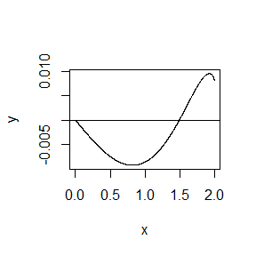

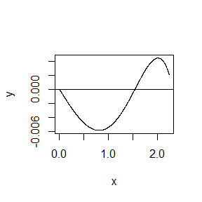

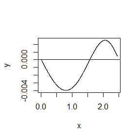

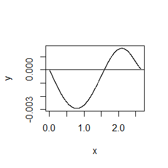

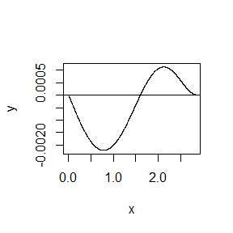

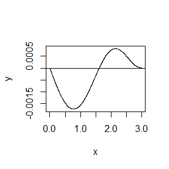

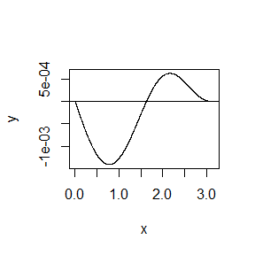

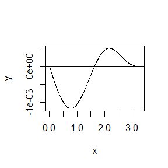

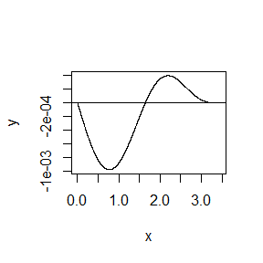

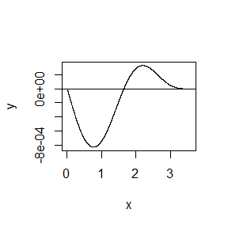

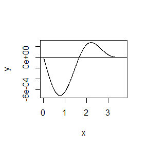

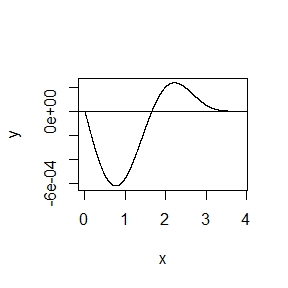

[13 more figures not shown]

```r
k<-c(4:25,100,500,1000)
for( i in 1:length(k)){
  a<-seq(0,sqrt(k[i]),0.001)
  r1<-pt(a*sqrt((k[i]-1)/(k[i]-a^2)),df=k[i]-1)
  r2<-pt(a*sqrt(k[i]/(k[i]+1-a^2)),df=k[i])
  plot(a,r1-r2,type="l",col="black",xlab='x',ylab='y')
  lines(a,r2,col="red")
  abline(0,0)
}
```

From the plot we can see the intersection points lie in (1,2),which means we should set interval to be c(1,2) in the function ‘uniroot’.

```r
k<-c(4:25,100,500,1000)
##location of the root ##
root<-numeric(length(k))
## the value of the function evaluated at that point##
value<-numeric(length(k))
for( i in 1:length(k)){
  out<-uniroot(function(a){
    pt(a*sqrt((k[i]-1)/(k[i]-a^2)),df=k[i]-1)-pt(a*sqrt(k[i]/(k[i]+1-a^2)),df=k[i])},lower=1,upper=2)
  root[i]<-out$root
  value[i]<-out$f.root
}
r<-cbind(root,value)
rownames(r)<-k
r
```

```
#>          root         value
#> 4    1.492103  1.155906e-09
#> 5    1.533556 -3.275814e-08
#> 6    1.562744 -6.195898e-09
#> 7    1.584430  4.654438e-09
#> 8    1.601185  9.614088e-09
#> 9    1.614521  1.345242e-08
#> 10   1.625390  1.569649e-08
#> 11   1.634419  1.663386e-08
#> 12   1.642038  1.668588e-08
#> 13   1.648554  1.619998e-08
#> 14   1.654190  1.541809e-08
#> 15   1.659114  1.449578e-08
#> 16   1.663452  1.352823e-08
#> 17   1.667303  1.257115e-08
#> 18   1.670745  1.165541e-08
#> 19   1.673840  1.079656e-08
#> 20   1.676637  1.000099e-08
#> 21   1.679178  9.269661e-09
#> 22   1.681496  8.600518e-09
#> 23   1.683620  7.989893e-09
#> 24   1.685572  7.433383e-09
#> 25   1.687373  6.926368e-09
#> 100  1.720608  1.221301e-10
#> 500  1.729755  5.512812e-12
#> 1000 1.730907  1.397327e-12
```

## 1.A-B-O blood type problem

- Let the three alleles be A, B, and O.
- Observed data: $n_{A.}=n_{AA}+n_{AO}=444(A-type)$ $n_{B.}=n_{BB}+n_{BO}=132(B-type),n_{OO}=361(O-type)$ $n_{AB}=63$
- Use EM algorithm to solve MLE of p and q (consider missing data $n_{AA}$and $n_{BB}$)
- Record the values of p and q that maximize the conditional likelihood in each EM steps, calculate the corresponding log-maximum likelihood values (for observed data), are they increasing?

Solution: Observed data: $n_{A.}~,~n_{B.}~,~n_{OO}~,~n_{AB}$

Complete data: $n_{AA},n_{AO}~,~n_{BB}~,n_{BO},~n_{OO}~,~n_{AB}$

Observed data likelihood:

$L(p,q|n_{A.},n_{B.},n_{OO},n_{AB})=(p^2+2pr)^{n_{A.}}(q^2+2qr)^{n_{B.}}(r^2)^{n_{OO}}(2pq)^{n_{AB}}$

Conplete data likelihood:

$$\begin{align}
L(p,q|n_{AA},n_{AO},n_{BB},n_{BO},n_{OO},n_{AB})&=\\
&(p^2)^{n_{AA}}(q^2)^{n_{BB}}{(r^2)}^{n_{OO}}(2pr)^{n_{AO}}(2qr)^{n_{BO}}(2pq)^{n_{AB}}\\
&\propto~p^{2n_{A.}}q^{2n_{B.}}(\frac{r}{p})^{n_{AO}}(\frac{r}{q})^{n_{BO}}(r^2)^{n_{OO}}(pq)^{n_{AB}}\\
\Rightarrow l(p,q)&=2n_{A.}logp+2n_{B.}logq\\
&+n_{AO}log(\frac{r}{p})+n_{BO}log(\frac{r}{q})\\
&+2n_{OO}log(r)+n_{AB}log(pq)
\end{align}$$
Set initial value to be $\hat{p_0}$,$\hat{q_0}$,and given $\hat{p_0}$,$\hat{q_0}$:

E-step:
$$\begin{align}
E_{\hat{p_0},\hat{q_0}}[l(p,q)|n_{A.},n_{B.},n_{OO},n_{AB}]&=2n_{A.}logp+2n_{B.}logq\\
&+E_{\hat{p_0},\hat{q_0}}(n_{AO}|n_{A.})log(\frac{r}{p})+E_{\hat{p_0},\hat{q_0}}(n_{BO}|n_{B.})log(\frac{r}{q})\\
&+2n_{OO}log(r)+n_{AB}log(pq)
\end{align}$$
$$Notice~that:n_{AO}|n_{A.}\sim B(n_{A.},\frac{2pr}{p^2+2pr})\\
And~n_{BO}|n_{B.}\sim B(n_{B.},\frac{2qr}{q^2+2qr})\\
MLE~of~r:\hat{r}=\sqrt{\frac{n_{OO}}{n}}$$

$$\begin{align}
E_{\hat{p_0},\hat{q_0}}[l(p,q)|n_{A.},n_{B.},n_{OO},n_{AB}]&=2n_{A.}logp+2n_{B.}logq+2n_{OO}log(r)+n_{AB}log(pq)\\
&+2log(\frac{r}{p})n_{A.}(\frac{1-\hat{p_0}-\hat{q_0}}{2-\hat{p_0}-2\hat{q_0}})+2log(\frac{r}{q})n_{B.}(\frac{1-\hat{p_0}-\hat{q_0}}{2-2\hat{p_0}-\hat{q_0}})
\end{align}$$

$$M-step:Q=E_{\hat{p_0},\hat{q_0}}[l(p,q)|n_{A.},n_{B.},n_{OO},n_{AB}]\\
Let:~~~\frac{\partial{Q}}{\partial{p}}=0~and~~ \frac{\partial{Q}}{\partial{q}}=0\\
For~convenience:a=n_{A.}(\frac{1-\hat{p_0}-\hat{q_0}}{2-\hat{p_0}-2\hat{q_0}}),b=n_{B.}(\frac{1-\hat{p_0}-\hat{q_0}}{2-2\hat{p_0}-\hat{q_0}})\\$$

{
$$\begin{aligned}
\frac{\partial{Q}}{\partial{p}}& =\frac{2n_{A.}}{p}-2\frac{n_{OO}}{1-p-q}+\frac{n_{AB}}{p}-2a(\frac{1}{1-p-q}+\frac{1}{p})-2b(\frac{1}{1-q-p})=0\\
\frac{\partial{Q}}{\partial{q}} &=\frac{2n_{B.}}{q}-2\frac{n_{OO}}{1-p-q}+\frac{n_{AB}}{q}-2b(\frac{1}{1-p-q}+\frac{1}{q})-2a(\frac{1}{1-q-p})=0
\end{aligned}$$

.

$$\left\{
\begin{aligned}
(2n_{OO}+2n_{A.}+n_{AB}+2b)p+(2n_{A.}+n_{AB}-2a)q=&2n_{A.}+n_{AB}-2a\\
(2n_{B.}+n_{AB}-2b)p+(2n_{OO}+2n_{B.}+n_{AB}+2a)q=&2n_{B.}+n_{AB}-2b\\
\end{aligned}
\right.$$

```r
## nA=nAA+nAO ##
nA<-444
##nB=nBB+nBO##
nB<-132
nOO<-361
nAB<-63
n<-nA+nB+nOO+nAB
##rhat##
r0<-sqrt(nOO/n)
n1<-nA/n
n2<-nB/n
##Solve equations to get p0 and q0##
##p^2+2pr=n1##
##q^2+2qr=n2##
p0<- -r0+sqrt(r0^2+n1)
q0<- -r0+sqrt(r0^2+n2)

##set max iterations to be 30##
iter<-30
p<-p0
q<-q0
dat<-matrix(data=NA,nrow=iter,ncol=3)

for(i in 1:iter){
  a<-nA*(1-p-q)/(2-p-2*q)
  b<-nB*(1-p-q)/(2-q-2*p)
  ##using matrix to solve p1 and p2##
  n<-matrix(c(2*nA+2*nOO+nAB+2*b,2*nA+nAB-2*a,2*nB+nAB-2*b,2*nB+2*nOO+nAB+2*a),nrow=2,byrow=T)
  rn<-matrix(c(2*nA+nAB-2*a,2*nB+nAB-2*b),nrow=2)

  result<-solve(n,rn)
  p<-result[1]
  q<-result[2]
  r<-1-q-p
  likelihood<-nA*log(p^2+2*p*r)+nB*log(q^2+2*q*r)+2*nOO*log(r)+nAB*log(2*p*q)

  dat[i,1]<-p
  dat[i,2]<-q
  dat[i,3]<-likelihood
}
dat
```

```
#>            [,1]      [,2]      [,3]
#>  [1,] 0.2973357 0.1026199 -1169.822
#>  [2,] 0.2975814 0.1026991 -1169.822
#>  [3,] 0.2976297 0.1027054 -1169.822
#>  [4,] 0.2976387 0.1027061 -1169.822
#>  [5,] 0.2976403 0.1027062 -1169.822
#>  [6,] 0.2976406 0.1027063 -1169.822
#>  [7,] 0.2976407 0.1027063 -1169.822
#>  [8,] 0.2976407 0.1027063 -1169.822
#>  [9,] 0.2976407 0.1027063 -1169.822
#> [10,] 0.2976407 0.1027063 -1169.822
#> [11,] 0.2976407 0.1027063 -1169.822
#> [12,] 0.2976407 0.1027063 -1169.822
#> [13,] 0.2976407 0.1027063 -1169.822
#> [14,] 0.2976407 0.1027063 -1169.822
```

[output cut: 16 more lines]

## 2.Exercises 3(page 204)

- Use both for loops and lapply() to fit linear models to the mtcars using the formulas stored in this list:

```r
data(mtcars)
###lapply###
formulas <- list(
  mpg ~ disp,
  mpg ~ I(1 / disp),
  mpg ~ disp + wt,
  mpg ~ I(1 / disp) + wt
)
model1<-lapply(formulas,lm,data=mtcars)
model1
```

```
#> [[1]]
#>
#> Call:
#> FUN(formula = X[[i]], data = ..1)
#>
#> Coefficients:
#> (Intercept)         disp
#>    29.59985     -0.04122
#>
#>
#> [[2]]
#>
#> Call:
#> FUN(formula = X[[i]], data = ..1)
#>
#> Coefficients:
#> (Intercept)    I(1/disp)
#>       10.75      1557.67
#>
#>
#> [[3]]
#>
#> Call:
#> FUN(formula = X[[i]], data = ..1)
#>
#> Coefficients:
#> (Intercept)         disp           wt
#>    34.96055     -0.01772     -3.35083
#>
#>
#> [[4]]
#>
#> Call:
#> FUN(formula = X[[i]], data = ..1)
#>
#> Coefficients:
#> (Intercept)    I(1/disp)           wt
#>      19.024     1142.560       -1.798
```

```r
###loops###
loops<-function(x,lm){
  out<-vector("list",length(x))
  for(i in seq_along(x)){
    out[[i]]<-lm(x[[i]],data=mtcars)
  }
  out
}
loops(formulas,lm)
```

```
#> [[1]]
#>
#> Call:
#> lm(formula = x[[i]], data = mtcars)
#>
#> Coefficients:
#> (Intercept)         disp
#>    29.59985     -0.04122
#>
#>
#> [[2]]
#>
#> Call:
#> lm(formula = x[[i]], data = mtcars)
#>
#> Coefficients:
#> (Intercept)    I(1/disp)
#>       10.75      1557.67
#>
#>
#> [[3]]
#>
#> Call:
#> lm(formula = x[[i]], data = mtcars)
#>
#> Coefficients:
#> (Intercept)         disp           wt
#>    34.96055     -0.01772     -3.35083
#>
#>
#> [[4]]
#>
#> Call:
#> lm(formula = x[[i]], data = mtcars)
#>
#> Coefficients:
#> (Intercept)    I(1/disp)           wt
#>      19.024     1142.560       -1.798
```

## 3.Excecises 3

- Note: the anonymous function is defined in Section 10.2
- Exercise 3: The following code simulates the performance of a t-test for non-normal data. Use sapply() and an anonymous function to extract the p-value from every trial.
- Extra challenge: get rid of the anonymous function by using [[ directly.

```r
 trials <- replicate(
   100,
   t.test(rpois(10, 10), rpois(7, 10)),
   simplify = FALSE
)
###sapply###
###anonymous function###
p1<-sapply(trials,function(x)x$p.value)
p1
```

```
#>   [1] 0.94971376 0.16820158 0.88906480 0.79187440 0.04392883 0.34159566
#>   [7] 0.79293155 0.58623207 0.73729147 0.76528455 0.19468438 0.96698418
#>  [13] 0.18706581 0.60625653 0.05330523 0.65891647 0.46148211 0.62320446
#>  [19] 0.60492717 0.06334428 0.33167449 0.75940612 0.83353117 0.82339643
#>  [25] 0.05661827 0.89322672 0.48794527 0.60480303 0.62488158 0.22608950
#>  [31] 0.60245401 0.51598949 0.08755804 0.59629935 0.52563386 0.24842645
#>  [37] 0.19740562 0.34320792 0.81048586 0.90452205 0.11913008 0.50672046
#>  [43] 0.12872276 0.91853613 0.69922976 0.64509617 0.72806952 0.96718172
#>  [49] 0.88309801 0.20984703 0.59512059 0.10806008 0.26934419 0.18755187
#>  [55] 0.97391733 0.65885519 0.14379030 0.96968624 0.13337629 0.83699961
#>  [61] 0.20949507 0.96049011 0.66515783 0.54683869 0.85380043 0.26946307
#>  [67] 0.80273544 0.73812316 0.87193026 0.40747268 0.51338384 0.85880425
#>  [73] 0.66651109 0.19257887 0.09190629 0.10546652 0.02000956 0.49556503
#>  [79] 0.71905750 0.26276974 0.60863405 0.60929221 0.34747170 0.52004503
#>  [85] 0.48102895 0.55638903 0.90899399 0.52713003 0.13900674 0.52623535
#>  [91] 0.95879543 0.68308969 0.23732981 0.13225638 0.26259579 0.84516863
#>  [97] 0.39581848 0.39554795 0.25596081 0.96646843
```

```r
###extra challenge###
###using "[[ "###
p2<-sapply(trials,"[[","p.value")
p2
```

```
#>   [1] 0.94971376 0.16820158 0.88906480 0.79187440 0.04392883 0.34159566
#>   [7] 0.79293155 0.58623207 0.73729147 0.76528455 0.19468438 0.96698418
#>  [13] 0.18706581 0.60625653 0.05330523 0.65891647 0.46148211 0.62320446
#>  [19] 0.60492717 0.06334428 0.33167449 0.75940612 0.83353117 0.82339643
#>  [25] 0.05661827 0.89322672 0.48794527 0.60480303 0.62488158 0.22608950
#>  [31] 0.60245401 0.51598949 0.08755804 0.59629935 0.52563386 0.24842645
#>  [37] 0.19740562 0.34320792 0.81048586 0.90452205 0.11913008 0.50672046
#>  [43] 0.12872276 0.91853613 0.69922976 0.64509617 0.72806952 0.96718172
#>  [49] 0.88309801 0.20984703 0.59512059 0.10806008 0.26934419 0.18755187
#>  [55] 0.97391733 0.65885519 0.14379030 0.96968624 0.13337629 0.83699961
#>  [61] 0.20949507 0.96049011 0.66515783 0.54683869 0.85380043 0.26946307
#>  [67] 0.80273544 0.73812316 0.87193026 0.40747268 0.51338384 0.85880425
#>  [73] 0.66651109 0.19257887 0.09190629 0.10546652 0.02000956 0.49556503
#>  [79] 0.71905750 0.26276974 0.60863405 0.60929221 0.34747170 0.52004503
#>  [85] 0.48102895 0.55638903 0.90899399 0.52713003 0.13900674 0.52623535
#>  [91] 0.95879543 0.68308969 0.23732981 0.13225638 0.26259579 0.84516863
#>  [97] 0.39581848 0.39554795 0.25596081 0.96646843
```

## Exercise6:

- Implement a combination of Map() and vapply() to create an lapply() variant that iterates in parallel over all of its inputs and stores its outputs in a vector (or a matrix). What arguments should the function take?

```r
##x:list/matrix##
##fun:function we need###
##output:type of output##
lapply1<-function(x,fun,output){
  my<-Map(fun,x)
  vapply(my,function(x)x,output)
}
lapply1(mtcars,mean,numeric(1))
```

```
#>        mpg        cyl       disp         hp       drat         wt       qsec
#>  20.090625   6.187500 230.721875 146.687500   3.596563   3.217250  17.848750
#>         vs         am       gear       carb
#>   0.437500   0.406250   3.687500   2.812500
```

```r
lapply1(mtcars,sd,double(1))
```

```
#>         mpg         cyl        disp          hp        drat          wt
#>   6.0269481   1.7859216 123.9386938  68.5628685   0.5346787   0.9784574
#>        qsec          vs          am        gear        carb
#>   1.7869432   0.5040161   0.4989909   0.7378041   1.6152000
```

- Write an Rcpp function for Exercise 9.4 (page 277)
- Compare the corresponding generated random numbers with those by the R function you wrote before using the function “qqplot”.
- Campare the computation time of the two functions with the function “microbenchmark”.
- Comments your results.

## Exercise 9.4

Implement a random walk Metropolis sampler for generating the standard Laplace distribution (see Exercise 3.2). For the increment, simulate from a normal distribution. Compare the chains generated when different variances are used for the proposal distribution. Also, compute the acceptance rates of each chain.

- Previous function

```r
library(Rcpp)
set.seed(12345)
rv<-function(s,x0,N){
  ##s: different sigma for different variances##
  ##x0:initial value##
  ##N:length of the chain##
  x<-numeric(N)
  u<-runif(N)
  x[1]<-x0

  for(i in 2:N){
    y<-rnorm(1,x[i-1],s)
    if(u[i]<=exp(abs(x[i-1])-abs(y)))
      x[i]<-y else{
        x[i]<-x[i-1]
      }
  }
  return(x)
}
```

- Rcpp

```r
sourceCpp(
  code= '
    #include<cmath>
    #include<Rcpp.h>
    using namespace Rcpp;

    double abs(double x){
      double y=0.5*exp(-fabs(x));
      return y;
    }
    // [[Rcpp::export]]
    NumericVector rvC(double s,double x0,int N) {
      NumericVector x(N);
      NumericVector u=runif(N);
      x[0]=x0;
      for(int i=1;i<N; i++){
        NumericVector y=rnorm(1,x[(i-1)],s);
        if(u[i]<=abs(y[0])/abs(x[(i-1)])){
          x[i]=y[0];
        }
        else{
          x[i]=x[(i-1)];
        }
      }
      return x;
    }
  '
)
```

- Compare different function

```r
s<-c(0.05,0.1)
x0<-20
N<-200
r<-matrix(data=NA,ncol=2,nrow=N)
rC<-matrix(data=NA,ncol=2,nrow=N)
for(i in 1:length(s)){
  r[ ,i]<-rv(s[i],x0,N)
  rC[ ,i]<-rvC(s[i],x0,N)
}
```

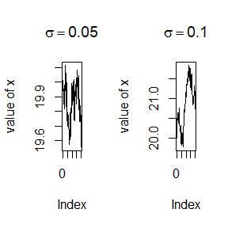

```r
par(mfrow = c(1,2))
for(i in 1:2){
  plot(r[,i],ylab='value of x',type='l',main = bquote(sigma == .(s[i])))
}
```

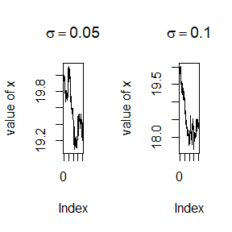

```r
par(mfrow=c(1,2))
for(i in 1:2){
  plot(rC[,i],ylab='value of x',type='l',main = bquote(sigma == .(s[i])))
}
```

* QQ plot

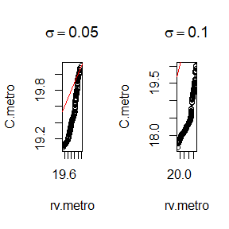

```r
par(mfrow=c(1,2))
for(i in 1:2){
  qqplot(r[,i],rC[,i],xlab="rv.metro",ylab="C.metro",
         main=bquote(sigma == .(s[i])))
  abline(0,1,col='red')
}
```

- Using microbenchmark

```r
library(microbenchmark)
microbenchmark(t1=rv(s[1],x0,N),t2=rvC(s[1],x0,N))
```

```
#> Unit: microseconds
#>  expr     min      lq       mean  median       uq       max neval
#>    t1 684.702 804.801 1196.96701 968.751 1214.251 17321.400   100
#>    t2  47.601  64.252   79.30906  77.651   91.101   162.301   100
```

```r
microbenchmark(t1=rv(s[2],x0,N),t2=rvC(s[2],x0,N))
```

```
#> Unit: microseconds
#>  expr     min       lq       mean  median        uq       max neval
#>    t1 702.801 791.1010 1177.39887 888.251 1340.4000 12178.800   100
#>    t2  47.002  51.2505   77.03807  63.451   85.9515   243.801   100
```